# survey_transphobia

### Race: control vs treatment

| Race | African American | Asian | Caucasian | Hispanic |
| --- | --- | --- | --- | --- |
| control | 52 | 2 | 52 | 111 |
| Treat | 53 | 1 | 62 | 96 |

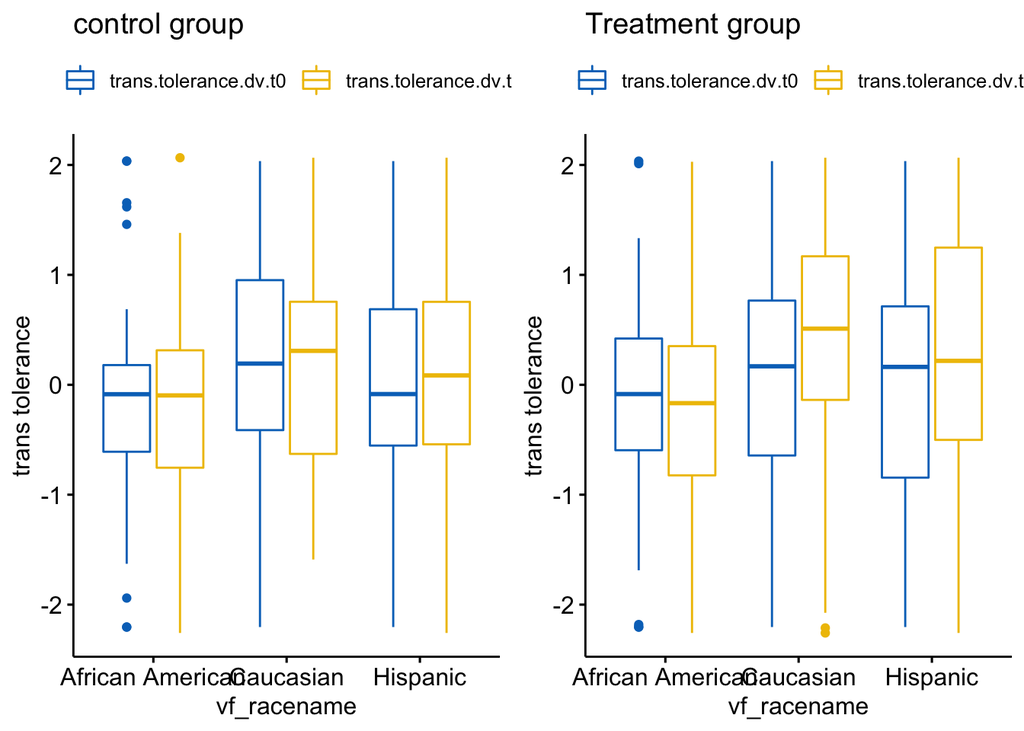

**Table S14.**

|  | Estimate | Std. Error | t value | *p* |
| --- | --- | --- | --- | --- |
| **white** | 0.376 | 0.171 | 2.201 | 0.015* |
| **hisp** | 0.343 | 0.109 | 3.143 | 0.001* |
| **black** | 0.163 | 0.163 | 1.001 | *n.s.* |

Effects at 3 Days by Race Registration, separately. Linear regression with clustered standard errors.

**Table S15a.**

|  | Estimate | Std. Error | *t* | *p* |
| --- | --- | --- | --- | --- |
| **Intercept** | 0.1882 | 0.3785 | 0.4971 | 0.6194 |
| **Treatment** | -0.8784 | 0.6556 | -1.34 | 0.181 |
| **White** | -0.3252 | 0.3851 | -0.8445 | 0.3988 |
| **Hisp** | -0.299 | 0.3819 | -0.7831 | 0.434 |
| **Black** | -0.2336 | 0.3854 | -0.6059 | 0.5449 |
| **White x Treat** | 1.158 | 0.6632 | 1.746 | 0.08154 |
| **Hisp X Treat** | 1.12 | 0.6598 | 1.697 | 0.09037 |
| **Black X Treat** | 0.9718 | 0.6639 | 1.464 | 0.144 |

Effects at 3 Days by Race Registration, Interaction Term. Linear regression with clustered standard errors.

**Table S15b.**

|  | Estimate | Std. Error | *t* | *p* |
| --- | --- | --- | --- | --- |
| **Intercept** | -0.1161 | 0.04089 | -2.839 | 0.004742 |
| **Treatment** | 0.2458 | 0.05951 | 4.131 | 4.343e-05 |
| **Black** | 0.07071 | 0.08347 | 0.8471 | 0.3974 |
| **Black X Treat** | -0.1524 | 0.1202 | -1.268 | 0.2054 |

Effects at 3 Days by Race Registration, Interaction Term. Linear regression with clustered standard errors.

**Table S15c.**

|  | Estimate | Std. Error | *t* | *p* |
| --- | --- | --- | --- | --- |
| **Intercept** | -0.08626 | 0.0413 | -2.089 | 0.03734 |
| **Treatment** | 0.1827 | 0.06046 | 3.022 | 0.002663 |
| **White** | -0.05079 | 0.08205 | -0.619 | 0.5362 |
| **White X Treat** | 0.09691 | 0.1171 | 0.8277 | 0.4083 |

Effects at 3 Days by Race Registration, Interaction Term. Linear regression with clustered standard errors.

### Canvasser and racename in Treatment group

(excluding Asians since there were only 3 in total)

| Canvasser Trans | African American | Hispanic | Caucasian |
| --- | --- | --- | --- |
| 0 | 33 | 62 | 43 |
| 1 | 19 | 33 | 17 |

Number of transgender canvassers in each race group after dropping Asian

#### Difference between transgender canvasser and non-transgender canvasser in each race

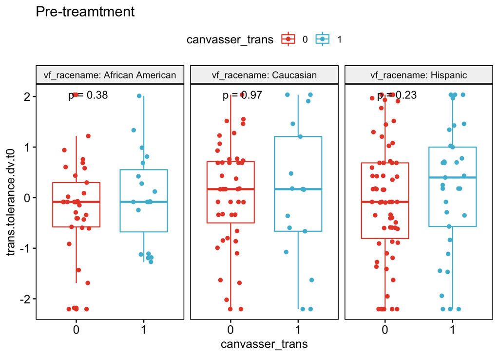

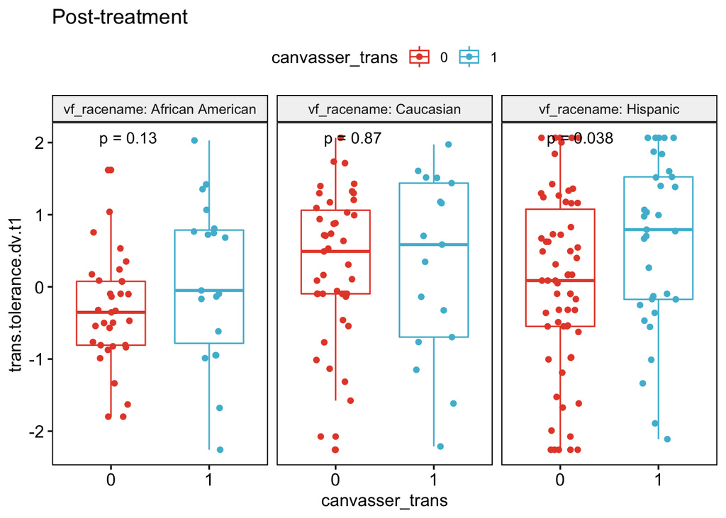

#### Difference between pre-treatment and post-treatment by race and canvasser

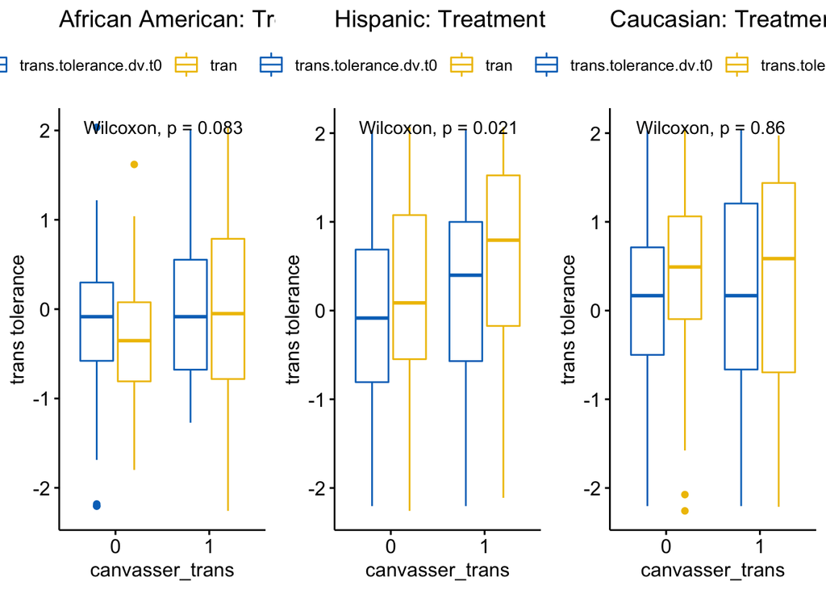

## Descriptive memo

Cleaning data for analyses on only on t1. Therefore removing other columns that are relavant for t2, t3 and t4.

```r
# Removing all results of t2 (3 week), t3 (6 week) and t4 (3 month)
t1_results <- t1[, -which(grepl('t2|t3|t4', names(t1)))]

# Pre-specified index of all primary outcomes at t0
all.dv.names.t0 <- c('miami_trans_law_t0', 'miami_trans_law2_t0', 'therm_trans_t0',
                      'gender_norms_sexchange_t0', 'gender_norms_moral_t0',
                      'gender_norms_abnormal_t0', 'gender_norm_trans_moral_wrong_t0')

# Remove primary outcomes at t0 and t1
t1_related <- t1_results[ , !(names(t1_results) %in% all.dv.names.t1)]
t1_related <- t1_related[ , !(names(t1_related) %in% all.dv.names.t0)]

# Remove gender non-conformity index at t0 and t1 since they used for
t1_related <- t1_related[ , !(names(t1_related) %in% gender.nonconformity.t0)]
t1_related <- t1_related[ , !(names(t1_related) %in% gender.nonconformity.t1)]

# Remove categorical variables
t1_related <- t1_related[, -which(grepl('vf_racename|vf_party', names(t1_related)))]

# Remove identifiers
identifiers <- c('id', 'block_ind', 'hh_id', 'canvasser_id')
t1_related <- t1_related[ , !(names(t1_related) %in% identifiers)]

# Remove contacted or responded (as they are all ones in this case)
tracking <- c('respondent_t0', 'respondent_t1', 'contacted')
t1_related <- t1_related[ , !(names(t1_related) %in% tracking)]

# Remove index that are directly related to the survey
survey_method <- c('scale_for_blocking_t0', 'cluster_level_t0_scale_mean','survey_language_t0', 'survey_language_es')
t1_related <- t1_related[ , !(names(t1_related) %in% survey_method)]

# Remove t1 s except trans.tolerance.dv.t1 and marijuana
t1_related <- t1_related[, -which(grepl('_t1|marijuana', names(t1_related)))]


# Removing treat_ind because it is assigned treatment and actual treatment is in exp_actual_convo
t1_related <- t1_related[, -which(grepl('treat_ind', names(t1_related)))]

# Remove canvas experience and rating
canvasser_info = c("canvass_recycling_rating","canvass_trans_ratingstart","canvass_trans_ratingsecond",
                   "canvass_trans_ratingend", "canvass_minutes","canvasser_experience")
t1_related <- t1_related[ , !(names(t1_related) %in% canvasser_info)]
```

```r
t1_related <- subset(t1_related, !is.na(t1_related$canvasser_trans))
df_split_trans <- modelr::resample_partition(t1_related, c(train=0.5, estim=0.5))
df_train_trans <- dplyr::as_tibble(df_split_trans$train)
df_est_trans<- dplyr::as_tibble(df_split_trans$estim)

outcome <- "trans.tolerance.dv.t1"
outcome_resid <- "t1.resid"
treatment <- "exp_actual_convo"
contexts <- colnames(t1_related)[1:24]
contexts <- contexts[contexts != treatment]
```

### Summarize context variables

|  | Mean | Stdev | Minimum | Lower quartile | Median | Upper quartile | Maximum |
| --- | --- | --- | --- | --- | --- | --- | --- |
| trans.tolerance.dv.t1 | 0.08 | 1.07 | -2.26 | -0.55 | 0.07 | 0.76 | 2.07 |
| vf_age | 49.85 | 17.09 | 18.00 | 37.00 | 52.00 | 62.00 | 90.00 |
| vf_female | 0.59 | 0.49 | 0.00 | 0.00 | 1.00 | 1.00 | 1.00 |
| vf_black | 0.25 | 0.43 | 0.00 | 0.00 | 0.00 | 0.00 | 1.00 |
| vf_white | 0.26 | 0.44 | 0.00 | 0.00 | 0.00 | 1.00 | 1.00 |
| vf_hispanic | 0.48 | 0.50 | 0.00 | 0.00 | 0.00 | 1.00 | 1.00 |
| vf_vg_14 | 0.67 | 0.47 | 0.00 | 0.00 | 1.00 | 1.00 | 1.00 |
| vf_vg_12 | 0.82 | 0.38 | 0.00 | 1.00 | 1.00 | 1.00 | 1.00 |
| vf_vg_10 | 0.56 | 0.50 | 0.00 | 0.00 | 1.00 | 1.00 | 1.00 |
| vf_democrat | 0.49 | 0.50 | 0.00 | 0.00 | 0.00 | 1.00 | 1.00 |
| vf_republican | 0.25 | 0.43 | 0.00 | 0.00 | 0.00 | 0.00 | 1.00 |
| gender_norm_daugher_t0 | -0.01 | 1.21 | -2.00 | -1.00 | 0.00 | 1.00 | 2.00 |
| ssm_t0 | 0.38 | 2.19 | -3.00 | -2.00 | 0.00 | 2.00 | 3.00 |
| therm_obama_t0 | 62.03 | 36.27 | 0.00 | 35.00 | 72.00 | 97.50 | 100.00 |
| therm_gay_t0 | 56.37 | 28.33 | 0.00 | 50.00 | 50.00 | 79.50 | 100.00 |
| therm_afams_t0 | 75.44 | 23.91 | 0.00 | 50.00 | 81.00 | 100.00 | 100.00 |
| ideology_t0 | 0.03 | 1.47 | -3.00 | -1.00 | 0.00 | 1.00 | 3.00 |
| religious_t0 | 2.06 | 1.74 | 0.00 | 1.00 | 1.00 | 4.00 | 5.00 |
| exposure_gay_t0 | 0.88 | 0.32 | 0.00 | 1.00 | 1.00 | 1.00 | 1.00 |
| exposure_trans_t0 | 0.29 | 0.45 | 0.00 | 0.00 | 0.00 | 1.00 | 1.00 |
| pid_t0 | 0.73 | 2.14 | -3.00 | -1.00 | 1.00 | 3.00 | 3.00 |
| sdo_scale | -0.03 | 0.52 | -1.00 | -0.13 | 0.00 | 0.00 | 2.64 |
| canvasser_trans | 0.35 | 0.48 | 0.00 | 0.00 | 0.00 | 1.00 | 1.00 |
| vf_independent | 0.24 | 0.43 | 0.00 | 0.00 | 0.00 | 0.00 | 1.00 |

## X-learners

### outcome = “trans.tolerance.dv.t1”

```
## [1] "Done with the first stage."
## [1] "Done with the second stage."
## [1] "Done with the propensity score estimation."
```

#### exp_actual_convo

| Variable | exp_actual_convo Q1 mean | exp_actual_convo Q1 se | exp_actual_convo Q2 mean | exp_actual_convo Q2 se | exp_actual_convo Q3 mean | exp_actual_convo Q3 se | exp_actual_convo Q4 mean | exp_actual_convo Q4 se | exp_actual_convo Q5 mean | exp_actual_convo Q5 se |
| --- | --- | --- | --- | --- | --- | --- | --- | --- | --- | --- |
| vf_age | 38.29 | 2.48 | 47.52 | 2.27 | 50.64 | 2.72 | 49.17 | 2.57 | 59.07 | 2.59 |
| vf_black | 0.14 | 0.05 | 0.40 | 0.08 | 0.31 | 0.07 | 0.38 | 0.08 | 0.10 | 0.05 |
| vf_white | 0.00 | 0.00 | 0.12 | 0.05 | 0.24 | 0.07 | 0.19 | 0.06 | 0.67 | 0.07 |
| vf_hispanic | 0.86 | 0.05 | 0.48 | 0.08 | 0.43 | 0.08 | 0.40 | 0.08 | 0.24 | 0.07 |
| therm_obama_t0 | 81.21 | 3.50 | 64.71 | 6.16 | 70.10 | 5.10 | 64.69 | 5.30 | 37.90 | 5.58 |
| ideology_t0 | 0.76 | 0.25 | -0.38 | 0.22 | 0.19 | 0.23 | 0.10 | 0.18 | -0.45 | 0.23 |
| religious_t0 | 2.40 | 0.28 | 2.98 | 0.23 | 2.38 | 0.28 | 1.40 | 0.23 | 0.98 | 0.18 |
| pid_t0 | 1.71 | 0.28 | 0.40 | 0.36 | 0.93 | 0.35 | 1.05 | 0.29 | -0.45 | 0.33 |
| cate | 0.19 | 0.00 | 0.25 | 0.00 | 0.29 | 0.00 | 0.33 | 0.00 | 0.39 | 0.01 |

### outcome = “t1.resid”

```
## [1] "Done with the first stage."
## [1] "Done with the second stage."
## [1] "Done with the propensity score estimation."
```

#### exp_actual_convo

| Variable | exp_actual_convo Q1 mean | exp_actual_convo Q1 se | exp_actual_convo Q2 mean | exp_actual_convo Q2 se | exp_actual_convo Q3 mean | exp_actual_convo Q3 se | exp_actual_convo Q4 mean | exp_actual_convo Q4 se | exp_actual_convo Q5 mean | exp_actual_convo Q5 se |
| --- | --- | --- | --- | --- | --- | --- | --- | --- | --- | --- |
| vf_age | 35.00 | 2.21 | 43.67 | 2.09 | 48.17 | 2.52 | 53.69 | 2.43 | 64.17 | 2.06 |
| vf_white | 0.07 | 0.04 | 0.17 | 0.06 | 0.19 | 0.06 | 0.31 | 0.07 | 0.48 | 0.08 |
| vf_vg_10 | 0.36 | 0.07 | 0.57 | 0.08 | 0.57 | 0.08 | 0.55 | 0.08 | 0.71 | 0.07 |
| vf_republican | 0.07 | 0.04 | 0.12 | 0.05 | 0.17 | 0.06 | 0.36 | 0.07 | 0.64 | 0.07 |
| ssm_t0 | 2.36 | 0.14 | 0.76 | 0.29 | 0.43 | 0.33 | -0.05 | 0.35 | -1.10 | 0.29 |
| therm_obama_t0 | 86.74 | 3.04 | 81.57 | 4.09 | 74.33 | 4.58 | 48.57 | 5.68 | 27.40 | 4.47 |
| therm_gay_t0 | 85.07 | 2.83 | 59.67 | 3.80 | 54.02 | 4.11 | 48.05 | 3.94 | 36.69 | 3.82 |
| therm_afams_t0 | 89.67 | 2.36 | 83.31 | 2.81 | 79.95 | 3.31 | 67.76 | 4.13 | 59.24 | 3.46 |
| ideology_t0 | 1.21 | 0.21 | 0.21 | 0.19 | 0.14 | 0.16 | -0.19 | 0.21 | -1.17 | 0.22 |
| pid_t0 | 1.98 | 0.26 | 1.48 | 0.29 | 1.05 | 0.29 | 0.19 | 0.35 | -1.05 | 0.30 |
| sdo_scale | -0.34 | 0.06 | -0.07 | 0.09 | -0.14 | 0.07 | 0.01 | 0.08 | 0.16 | 0.07 |
| cate | 0.15 | 0.01 | 0.22 | 0.00 | 0.25 | 0.00 | 0.30 | 0.00 | 0.36 | 0.01 |

## Post-lasso

### outcome = trans.tolerance.dv.t1

|  | Estimate | Std. Error | t value | Pr(>\|t\|) |
| --- | --- | --- | --- | --- |
| (Intercept) | -0.02 | 0.05 | -0.53 | 0.60 |
| vf_age | 0.00 | 0.00 | -1.08 | 0.28 |
| gender_norm_daugher_t0 | -0.14 | 0.03 | -4.97 | 0.00 |
| ssm_t0 | 0.19 | 0.02 | 7.91 | 0.00 |
| therm_obama_t0 | 0.00 | 0.00 | -0.41 | 0.68 |
| therm_gay_t0 | 0.01 | 0.00 | 5.12 | 0.00 |
| therm_afams_t0 | 0.00 | 0.00 | 1.15 | 0.25 |
| religious_t0 | -0.03 | 0.03 | -1.08 | 0.28 |
| pid_t0 | 0.02 | 0.02 | 1.02 | 0.31 |
| exp_actual_convo | 0.21 | 0.07 | 3.22 | 0.00 |
| vf_age:exp_actual_convo | 0.00 | 0.00 | 0.91 | 0.36 |
| therm_obama_t0:exp_actual_convo | 0.00 | 0.00 | 0.21 | 0.84 |
| therm_gay_t0:exp_actual_convo | 0.00 | 0.00 | 0.49 | 0.62 |
| therm_afams_t0:exp_actual_convo | 0.00 | 0.00 | -0.60 | 0.55 |
| religious_t0:exp_actual_convo | -0.06 | 0.04 | -1.40 | 0.16 |

### outcome = t1.resid

|  | Estimate | Std. Error | t value | Pr(>\|t\|) |
| --- | --- | --- | --- | --- |
| (Intercept) | -0.1 | 0.04 | -2.59 | 0.01 |
| exp_actual_convo | 0.2 | 0.05 | 3.90 | 0.00 |

## Causal Tree

### Correlation table by cate leaf

### outcome = trans.tolerance.dv.t1

```
##                  Variable exp_actual_convo
## 1                vf_white         0.77***
## 2            therm_gay_t0         0.62*
## 3                vf_vg_10         0.51
## 4         exposure_gay_t0         0.47
## 5               vf_female        -0.41
## 6          vf_independent        -0.38
## 7                  ssm_t0         0.34
## 8             vf_hispanic        -0.33
## 9          therm_afams_t0         0.32
## 10               vf_vg_12         0.29
## 11            vf_democrat         0.28
## 12                 vf_age         0.26
## 13      exposure_trans_t0         0.25
## 14 gender_norm_daugher_t0         0.23
## 15        canvasser_trans         0.22
## 16           religious_t0        -0.22
## 17               vf_vg_14         0.22
## 18               vf_black        -0.22
## 19         therm_obama_t0        -0.12
## 20                 pid_t0         0.11
## 21              sdo_scale        -0.11
## 22          vf_republican          0.1
## 23            ideology_t0        -0.07
```

### outcome = t1.resid

```
##                  Variable exp_actual_convo
## 1         canvasser_trans         0.54**
## 2  gender_norm_daugher_t0        -0.51*
## 3               vf_female         0.48*
## 4             vf_hispanic         0.41
## 5             ideology_t0          0.4
## 6                  pid_t0         0.33
## 7          vf_independent         0.33
## 8          therm_afams_t0        -0.31
## 9            therm_gay_t0         0.29
## 10         therm_obama_t0         0.27
## 11                 ssm_t0         0.27
## 12               vf_white        -0.23
## 13          vf_republican        -0.21
## 14               vf_black        -0.16
## 15           religious_t0        -0.15
## 16      exposure_trans_t0        -0.13
## 17               vf_vg_12        -0.11
## 18               vf_vg_14        -0.09
## 19            vf_democrat        -0.08
## 20               vf_vg_10        -0.07
## 21                 vf_age        -0.07
## 22        exposure_gay_t0        -0.06
## 23              sdo_scale         0.02
```